# Project 3: Airline fares and Credit Card Loans

Cal Parker and Gabriella Martin

2022-11-24

## Question 1.

Our chosen panel data set consists of cost data with 90 observations for 6 U.S. Airline companies over 15 years (1970-84)

Our Predictors: I (Airline): I indicates the different airline companies. For our data set, we have a total of 6 different U.S. airlines. T (Year): T indicates the year for which cross-sectional data is being observed. The duration of T for our data is from 1970 -1984, for a total of 15 years. PF (Fuel Price): This is the global average price paid at the refinery for jet fuel at a time T. This fuel price is determined by a set contract with the airline and the fuel company. LF (Load Factor): This is a measure of how much of an airline’s passenger carrying capacity has been utilized. It generally depends upon flight seating capacity, airline route, demand, etc., Bigger airplanes would have the capacity for a bigger load factor. Q (revenue passenger miles): This metric shows the number of miles traveled by paying passengers and is typically an airline traffic statistic. Cost (1000, the data): Depends on various factors including our predictors such as Fuel Price, Load Factor, as well as other predictors such as Lease & Depreciation, Aircraft Maintenance, Labor, and Airport Handling Charges.

Our dependent variable is cost, called “C”

With our regression analysis, we will explore how various indicators and predictors affect the cost of flying for different airline companies over time. This analysis would be useful for airline companies that are interested in lowering their average total costs over time. This would also be useful for companies to figure out the most efficient way to allocate resources in order to minimize average variable costs while maintaining revenue in order to maximize their profit margins. While the profits for airline companies were already trending downward, this issue is now especially important in the wake of the Covid-19 pandemic since we saw a massive decrease in the amount of people flying which led to some airline companies even filing for bankruptcy.

```r
setwd("C:/Users/cal3p/OneDrive/Desktop/Max Desktop/UCLA Folder Max")
#loads data
airlinepaneldata<-read_csv("PanelData.csv")
```

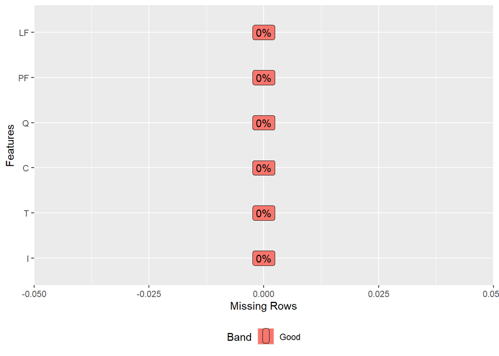

```r
plot_missing(airlinepaneldata, missing_only = FALSE)
```

We see that nothing is missing in our data.

## Question 2.

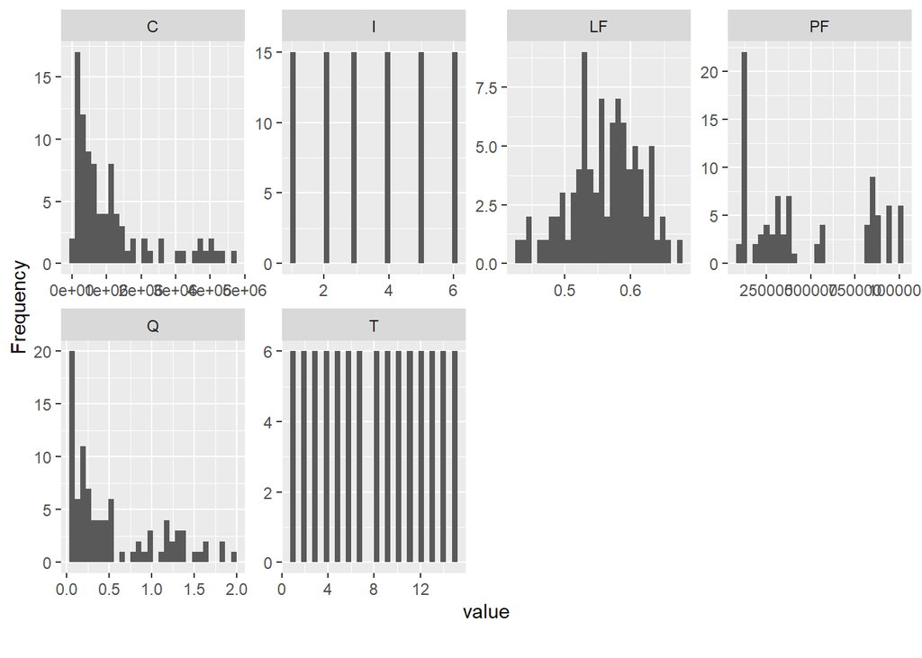

```r
#plots histograms tables and boxplots
plot_histogram(airlinepaneldata)
```

```r
kable(summary(airlinepaneldata))
```

|  | I | T | C | Q | PF | LF |
| --- | --- | --- | --- | --- | --- | --- |
|  | Min. :1.0 | Min. : 1 | Min. : 68978 | Min. :0.03768 | Min. : 103795 | Min. :0.4321 |
|  | 1st Qu.:2.0 | 1st Qu.: 4 | 1st Qu.: 292046 | 1st Qu.:0.14213 | 1st Qu.: 129848 | 1st Qu.:0.5288 |
|  | Median :3.5 | Median : 8 | Median : 637001 | Median :0.30503 | Median : 357434 | Median :0.5661 |
|  | Mean :3.5 | Mean : 8 | Mean :1122524 | Mean :0.54499 | Mean : 471683 | Mean :0.5605 |
|  | 3rd Qu.:5.0 | 3rd Qu.:12 | 3rd Qu.:1345968 | 3rd Qu.:0.94528 | 3rd Qu.: 849840 | 3rd Qu.:0.5947 |
|  | Max. :6.0 | Max. :15 | Max. :4748320 | Max. :1.93646 | Max. :1015610 | Max. :0.6763 |

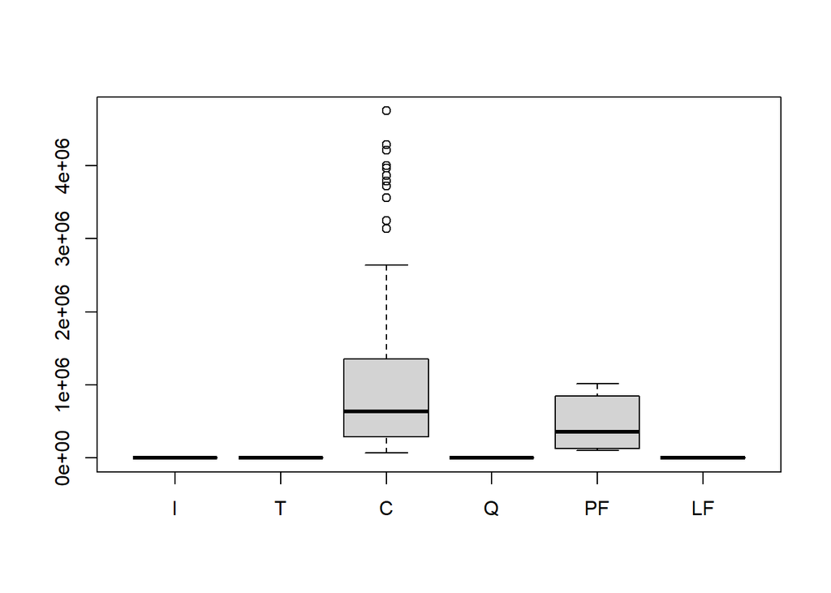

```r
boxplot(airlinepaneldata)
```

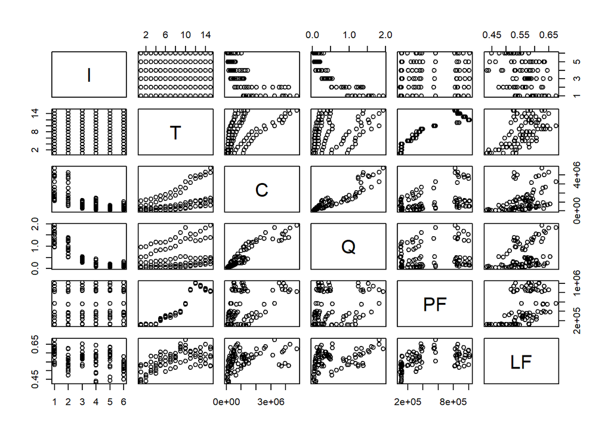

```r
plot(airlinepaneldata)
```

Looking at our box plots, we can see that C appears to have some outliers and is on a bigger scale.

### Correlation plots.

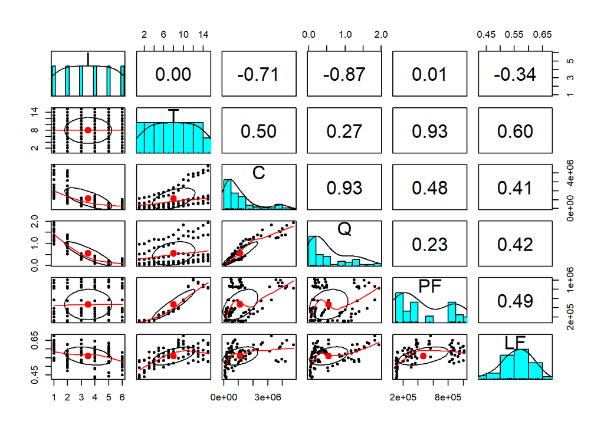

```r
#creates a correlation plot
pairs.panels(airlinepaneldata)
```

## Question 3.

### Pooled Model

```r
#creates three regressions Pooled fixed and random
pooledreg<-plm(C~Q+PF+LF, airlinepaneldata, index = c("I", "T"), model = "pooling")
fixedeffectsreg<-plm(C~Q+PF+LF, data = airlinepaneldata, index = c("I", "T"), model = "within")
randomeffectsreg<-plm(C~Q+PF+LF, data = airlinepaneldata, index = c("I", "T"), model = "random")

#Shows output of the pooled model
summary(pooledreg)
```

```
## Pooling Model
##
## Call:
## plm(formula = C ~ Q + PF + LF, data = airlinepaneldata, model = "pooling",
##     index = c("I", "T"))
##
## Balanced Panel: n = 6, T = 15, N = 90
##
## Residuals:
##    Min. 1st Qu.  Median 3rd Qu.    Max.
## -520654 -250270   37333  208690  849700
##
## Coefficients:
##                Estimate  Std. Error t-value  Pr(>|t|)
## (Intercept)  1.1586e+06  3.6059e+05  3.2129   0.00185 **
## Q            2.0261e+06  6.1807e+04 32.7813 < 2.2e-16 ***
## PF           1.2253e+00  1.0372e-01 11.8138 < 2.2e-16 ***
## LF          -3.0658e+06  6.9633e+05 -4.4027 3.058e-05 ***
## ---
## Signif. codes:  0 '***' 0.001 '**' 0.01 '*' 0.05 '.' 0.1 ' ' 1
##
## Total Sum of Squares:    1.2647e+14
## Residual Sum of Squares: 6.8177e+12
## R-Squared:      0.94609
## Adj. R-Squared: 0.94421
## F-statistic: 503.118 on 3 and 86 DF, p-value: < 2.22e-16
```

Ho: Pooled OLS is not the appropriate estimator H1: Pooled OLS is the appropriate estimator

Our P-value is less than .05 and therefore we can reject the null hypothesis and accept the alternative hypothesis. Our conclusion, consequently, is that the pooled OLS can be a good estimator. Nevertheless, pooled OLS does not consider the heterogeneity across airline firms or years.

Looking at our output, all of our estimates are statistically significant at the 99.9% confidence level. Our estimates for each variable suggest the following: A one unit change in Q (output) increases C (cost) by nearly 2 million dollars. A one unit change in PF (fuel price) minimally affects C (cost) – by 1.225 units. Lastly, for LF (load factor) a one unit change decreases C (cost) by roughly 3 million dollars. Additionally, we should note that the R^2 is quite high (.9461), meaning that are model explains our data quite well.

It is important to note that pooled OLS disregards all individual-specific effects of panel data. Despite the low P-value and high R^2, which suggests that the model is fit to use, we cannot rely on the pooled model because it ignores heterogeneity.

### Fixed Model

```r
#Shows output of the fixed effects model
summary(fixedeffectsreg)
```

```
## Oneway (individual) effect Within Model
##
## Call:
## plm(formula = C ~ Q + PF + LF, data = airlinepaneldata, model = "within",
##     index = c("I", "T"))
##
## Balanced Panel: n = 6, T = 15, N = 90
##
## Residuals:
##    Min. 1st Qu.  Median    Mean 3rd Qu.    Max.
## -551783 -159259    1796       0  137226  499296
##
## Coefficients:
##       Estimate  Std. Error t-value  Pr(>|t|)
## Q   3.3190e+06  1.7135e+05 19.3694 < 2.2e-16 ***
## PF  7.7307e-01  9.7319e-02  7.9437 9.698e-12 ***
## LF -3.7974e+06  6.1377e+05 -6.1869 2.375e-08 ***
## ---
## Signif. codes:  0 '***' 0.001 '**' 0.01 '*' 0.05 '.' 0.1 ' ' 1
##
## Total Sum of Squares:    5.0776e+13
## Residual Sum of Squares: 3.5865e+12
## R-Squared:      0.92937
## Adj. R-Squared: 0.92239
## F-statistic: 355.254 on 3 and 81 DF, p-value: < 2.22e-16
```

### Fixed Effects model.

Note, that we do not have an intercept here because the slope of these lines is now fixed.

Our P-Value is less than .05, showing that our overall model is good.

Our output shows again that the individual effect of Q, PF, and LF are significant at the 99.9% confidence level. The interpretation of our coefficients is as follows: A one unit change in Q produces a 3.3190^6 increase in cost. A one unit change in PF will produce a .77307 increase in cost. And lastly, a one unit change in LF will result in a 3.7974^6 decrease in cost. Our R^2 is high indicating more variability explained by the model.

### Random Effects Model.

```r
#shows output of the random effects model
summary(randomeffectsreg)
```

```
## Oneway (individual) effect Random Effect Model
##    (Swamy-Arora's transformation)
##
## Call:
## plm(formula = C ~ Q + PF + LF, data = airlinepaneldata, model = "random",
##     index = c("I", "T"))
##
## Balanced Panel: n = 6, T = 15, N = 90
##
## Effects:
##                     var   std.dev share
## idiosyncratic 4.428e+10 2.104e+05 0.793
## individual    1.154e+10 1.074e+05 0.207
## theta: 0.5486
##
## Residuals:
##    Min. 1st Qu.  Median 3rd Qu.    Max.
## -535726 -238494   49890  207491  722934
##
## Coefficients:
##                Estimate  Std. Error z-value  Pr(>|z|)
## (Intercept)  1.0743e+06  3.7747e+05  2.8461  0.004427 **
## Q            2.2886e+06  1.0949e+05 20.9015 < 2.2e-16 ***
## PF           1.1236e+00  1.0344e-01 10.8622 < 2.2e-16 ***
## LF          -3.0850e+06  7.2568e+05 -4.2512 2.126e-05 ***
## ---
## Signif. codes:  0 '***' 0.001 '**' 0.01 '*' 0.05 '.' 0.1 ' ' 1
##
## Total Sum of Squares:    6.6198e+13
## Residual Sum of Squares: 5.8721e+12
## R-Squared:      0.91129
## Adj. R-Squared: 0.9082
## Chisq: 883.501 on 3 DF, p-value: < 2.22e-16
```

Our output for our random effects model shows statistical significance for our estimates at the 99.9% confidence level (individual effect of Q, PF, and LF are significant). The P-value is less than .05 and therefore the overall model is good.

In this model, our coefficient for Q is 2.28886^6, indicating that a one unit change in Q results in a roughly 2.3 million increase in cost. A one unit change in PF results in a 1.1236 increase in cost. A one unit change in LF results in a 3.0850^6 (roughly 3.1 million) decrease in cost. Our R^2 is similarly high in the random effects model, but it is slightly lower than both the pooled model and the fixed effects model.

### Residual Plots.

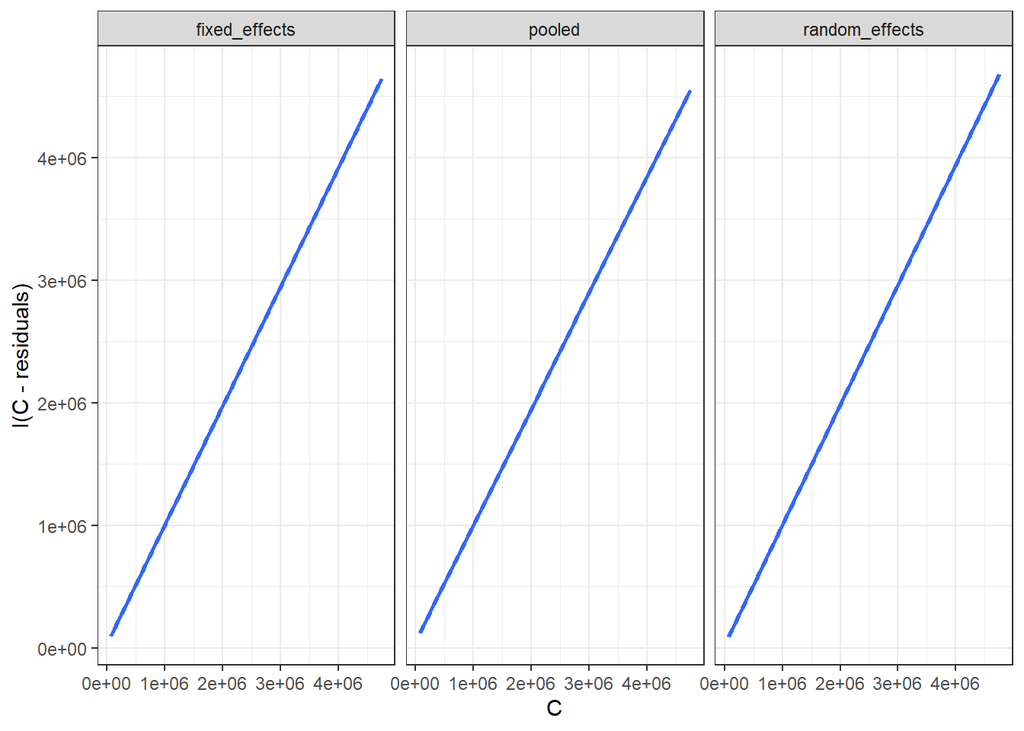

```r
## creates three graphs for each model and plots the residuals and the dependent variables
data.frame(
  C = airlinepaneldata$C,
  pooled = pooledreg$residuals,
  random_effects = randomeffectsreg$residuals,
  fixed_effects = fixedeffectsreg$residuals
) %>%
  pivot_longer(-C, names_to = "model_type", values_to = "residuals") %>%
  ggplot(aes(C, y = I(C - residuals))) +
  geom_point() +
  stat_smooth(formula = "y ~ x", se = FALSE, method = "lm") +
  facet_wrap(~ model_type) +
  theme_bw()
```

### fitted distributions

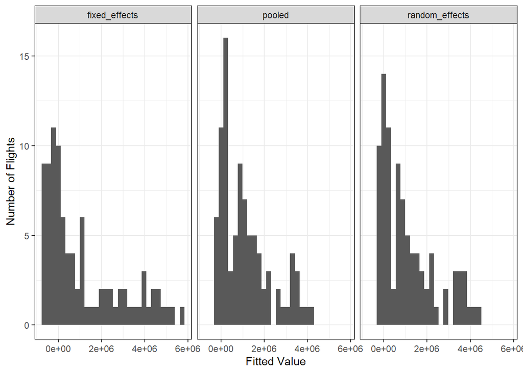

```r
## Creates histograms for each model fitted values on x axis and number of flights on y axis.
data.frame(
  C = airlinepaneldata$C,
  pooled = predict(pooledreg, airlinepaneldata),
  random_effects = predict(randomeffectsreg, airlinepaneldata),
  fixed_effects = predict(fixedeffectsreg, airlinepaneldata)
) %>%
  pivot_longer(-C, names_to = "model_type", values_to = "fitted") %>%
  ggplot(aes(fitted)) +
  geom_histogram(bins = 30) +
  labs(y = "Number of Flights", x = "Fitted Value") +
  facet_wrap(~ model_type) +
  theme_bw()
```

### First Hausman Test to compare the pooled and fixed effects model.

```r
#hausman test of pooledreg and fixedeffectsreg
phtest(pooledreg, fixedeffectsreg)
```

```
##
##  Hausman Test
##
## data:  C ~ Q + PF + LF
## chisq = 65.401, df = 3, p-value = 4.118e-14
## alternative hypothesis: one model is inconsistent
```

```r
#hausman test of randomeffectsreg and fixedeffectsreg
phtest(randomeffectsreg, fixedeffectsreg)
```

```
##
##  Hausman Test
##
## data:  C ~ Q + PF + LF
## chisq = 60.87, df = 3, p-value = 3.832e-13
## alternative hypothesis: one model is inconsistent
```

### Second Hausman test comparing fixed effects and random effects.

Pooled regression has the least amount of controls/constraints, whereas the random effects will add the variables we are using as constraints. Fixed effects is the most constrained of the three models because it does not allow our intercept to vary randomly. After doing both of these Hausman tests, which both showed that fixed effects should be used, we can conclude that the fixed effect model is an appropriate estimator and random effects are probably correlated with Xit.

## **Qualitative Dependent Variable Models**

## Question 1.

The explanatory indicator variable credit.policy shows us whether the creditor meets the criteria provided by LendingClub.com to qualify for a loan. credit.policy Indicator Variable values: 0: customer doesnt meet the credit underwriting criteria of the Lending 1: customer meets the credit underwriting criteria of the Lending

Our continuous variables: int.rate: gives a value of the interest rate measured in basis points installment: the monthly installments owed to the borrower measured in USD log.annual.inc: the natural log of the borrowers’ income dti: the borrower’s debt to income ratio fico: the FICO score of the borrower days.with.credit.line: the number of days that the borrower has had access to the credit line revol.bal: the borrowers’ revolving balance revol.util: the borrowers’ revolving line that has been utilized while they have access to the credit line inq.last.6mths: the borrower’s number of inquiries by creditors in the last 6 months delinq.2yrs: the number of times the borrower has been deliquient past 30 days of the payment due date public.rec: the number of derogatory public records the borrower has had

## Question 2

```r
loans_data<-read_csv("loans.csv")
```

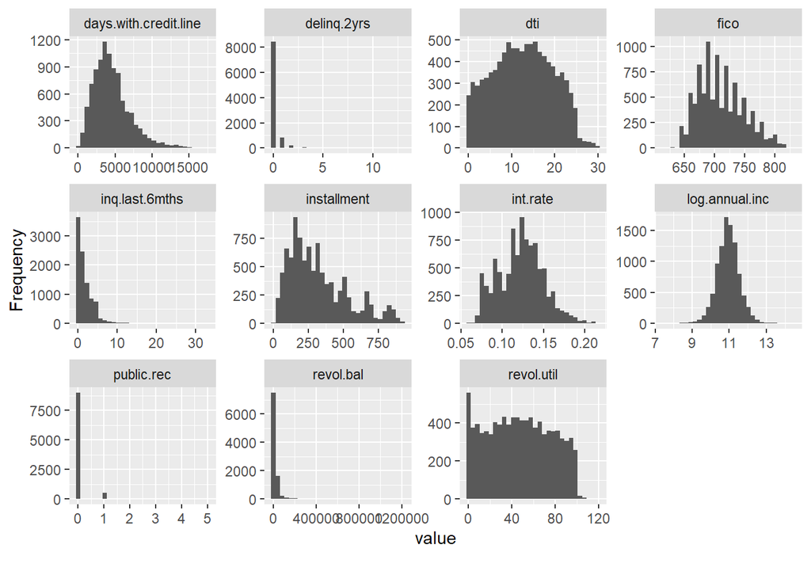

```r
plot_histogram(loans_data)
```

```r
kable(summary(loans_data))
```

|  | credit.policy | purpose | int.rate | installment | log.annual.inc | dti | fico | days.with.credit.line | revol.bal | revol.util | inq.last.6mths | delinq.2yrs | public.rec | not.fully.paid |
| --- | --- | --- | --- | --- | --- | --- | --- | --- | --- | --- | --- | --- | --- | --- |
|  | Min. :0.000 | Length:9578 | Min. :0.0600 | Min. : 15.67 | Min. : 7.548 | Min. : 0.000 | Min. :612.0 | Min. : 179 | Min. : 0 | Min. : 0.00 | Min. : 0.000 | Min. : 0.0000 | Min. :0.0000 | Min. :0.0000 |
|  | 1st Qu.:1.000 | Class :character | 1st Qu.:0.1039 | 1st Qu.:163.77 | 1st Qu.:10.558 | 1st Qu.: 7.213 | 1st Qu.:682.0 | 1st Qu.: 2820 | 1st Qu.: 3187 | 1st Qu.: 22.70 | 1st Qu.: 0.000 | 1st Qu.: 0.0000 | 1st Qu.:0.0000 | 1st Qu.:0.0000 |
|  | Median :1.000 | Mode :character | Median :0.1221 | Median :268.95 | Median :10.928 | Median :12.665 | Median :707.0 | Median : 4140 | Median : 8596 | Median : 46.40 | Median : 1.000 | Median : 0.0000 | Median :0.0000 | Median :0.0000 |
|  | Mean :0.805 | NA | Mean :0.1226 | Mean :319.09 | Mean :10.932 | Mean :12.607 | Mean :710.8 | Mean : 4562 | Mean : 16914 | Mean : 46.87 | Mean : 1.572 | Mean : 0.1638 | Mean :0.0621 | Mean :0.1601 |
|  | 3rd Qu.:1.000 | NA | 3rd Qu.:0.1407 | 3rd Qu.:432.76 | 3rd Qu.:11.290 | 3rd Qu.:17.950 | 3rd Qu.:737.0 | 3rd Qu.: 5730 | 3rd Qu.: 18250 | 3rd Qu.: 71.00 | 3rd Qu.: 2.000 | 3rd Qu.: 0.0000 | 3rd Qu.:0.0000 | 3rd Qu.:0.0000 |
|  | Max. :1.000 | NA | Max. :0.2164 | Max. :940.14 | Max. :14.528 | Max. :29.960 | Max. :827.0 | Max. :17640 | Max. :1207359 | Max. :119.00 | Max. :33.000 | Max. :13.0000 | Max. :5.0000 | Max. :1.0000 |
|  | NA | NA | NA | NA | NA’s :4 | NA | NA | NA’s :29 | NA | NA’s :62 | NA’s :29 | NA’s :29 | NA’s :29 | NA |

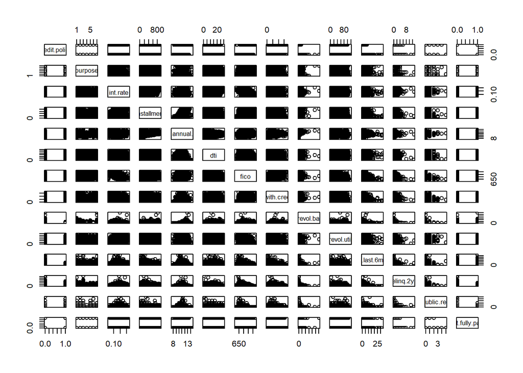

```r
plot(loans_data)
```

Days with credit line appears almost normal with a right tail. Log annual income looks normalally distributed. Installmens and fico look relatively chi squared distributed with giant jumps. Public.rec purpose delinq inq.last.6mths and revolv.bal exponentially decline from left to right. Revol is almost uniformly distributed. DTI is just a blob with jumps in the middle. The correlation graph is really hard to interpret because of the large quantity of variables included in the dataset.

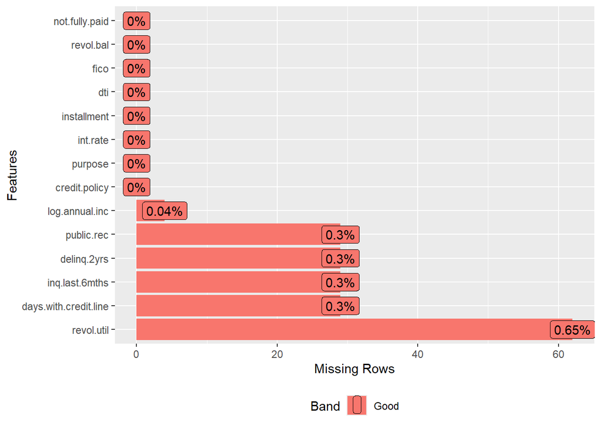

```r
plot_missing(loans_data, missing_only = FALSE)
```

Our data has almost no missing values.

### Correlation plots

Next, we will run our correlation plots.

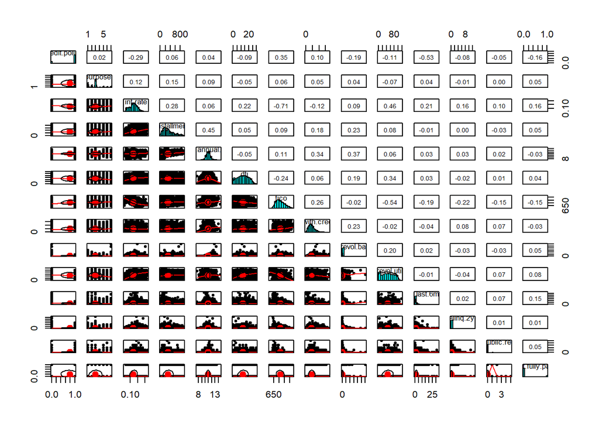

```r
pairs.panels(loans_data)
```

## Question 3

### Models

```r
##"Linear Probability Model"
LPMmodel<-lm(not.fully.paid~credit.policy+purpose+int.rate+installment+log.annual.inc+dti+fico+days.with.credit.line+revol.bal+revol.util+inq.last.6mths+delinq.2yrs+public.rec, data = loans_data)
kable(tidy(LPMmodel), digits=4,align='c', caption = "Linear Probability Model")
```

Linear Probability Model

| term | estimate | std.error | statistic | p.value |
| --- | --- | --- | --- | --- |
| (Intercept) | 1.3504 | 0.1653 | 8.1704 | 0.0000 |
| credit.policy | -0.0605 | 0.0120 | -5.0644 | 0.0000 |
| purposecredit_card | -0.0635 | 0.0128 | -4.9678 | 0.0000 |
| purposedebt_consolidation | -0.0431 | 0.0098 | -4.3832 | 0.0000 |
| purposeeducational | 0.0149 | 0.0207 | 0.7187 | 0.4724 |
| purposehome_improvement | 0.0092 | 0.0162 | 0.5690 | 0.5693 |
| purposemajor_purchase | -0.0360 | 0.0187 | -1.9270 | 0.0540 |
| purposesmall_business | 0.0878 | 0.0169 | 5.1858 | 0.0000 |
| int.rate | 0.1653 | 0.2345 | 0.7050 | 0.4808 |
| installment | 0.0001 | 0.0000 | 6.5390 | 0.0000 |
| log.annual.inc | -0.0493 | 0.0075 | -6.5864 | 0.0000 |
| dti | -0.0003 | 0.0006 | -0.5147 | 0.6068 |
| fico | -0.0010 | 0.0002 | -5.5191 | 0.0000 |
| days.with.credit.line | 0.0000 | 0.0000 | 1.1024 | 0.2703 |
| revol.bal | 0.0000 | 0.0000 | 3.5011 | 0.0005 |
| revol.util | 0.0003 | 0.0002 | 1.8270 | 0.0677 |
| inq.last.6mths | 0.0147 | 0.0020 | 7.3346 | 0.0000 |
| delinq.2yrs | -0.0127 | 0.0071 | -1.7822 | 0.0748 |
| public.rec | 0.0402 | 0.0142 | 2.8291 | 0.0047 |

```r
##"Probit Model"
olsprobit<-glm(not.fully.paid~credit.policy+purpose+int.rate+installment+log.annual.inc+dti+fico+days.with.credit.line+revol.bal+revol.util+inq.last.6mths+delinq.2yrs+public.rec, family=binomial(link="probit"), data=loans_data)
kable(tidy(olsprobit), digits=4, align='c', caption="Probit Model")
```

Probit Model

| term | estimate | std.error | statistic | p.value |
| --- | --- | --- | --- | --- |
| (Intercept) | 4.5373 | 0.7246 | 6.2620 | 0.0000 |
| credit.policy | -0.1977 | 0.0486 | -4.0730 | 0.0000 |
| purposecredit_card | -0.2961 | 0.0591 | -5.0080 | 0.0000 |
| purposedebt_consolidation | -0.1844 | 0.0431 | -4.2836 | 0.0000 |
| purposeeducational | 0.0532 | 0.0864 | 0.6159 | 0.5380 |
| purposehome_improvement | 0.0415 | 0.0707 | 0.5869 | 0.5573 |
| purposemajor_purchase | -0.1825 | 0.0887 | -2.0569 | 0.0397 |
| purposesmall_business | 0.3076 | 0.0678 | 4.5385 | 0.0000 |
| int.rate | 0.9537 | 0.9868 | 0.9665 | 0.3338 |
| installment | 0.0007 | 0.0001 | 6.7943 | 0.0000 |
| log.annual.inc | -0.2249 | 0.0335 | -6.7218 | 0.0000 |
| dti | -0.0005 | 0.0026 | -0.2144 | 0.8303 |
| fico | -0.0048 | 0.0008 | -6.0911 | 0.0000 |
| days.with.credit.line | 0.0000 | 0.0000 | 1.0278 | 0.3041 |
| revol.bal | 0.0000 | 0.0000 | 3.0869 | 0.0020 |
| revol.util | 0.0014 | 0.0007 | 1.9512 | 0.0510 |
| inq.last.6mths | 0.0510 | 0.0080 | 6.3839 | 0.0000 |
| delinq.2yrs | -0.0532 | 0.0310 | -1.7153 | 0.0863 |
| public.rec | 0.1451 | 0.0566 | 2.5623 | 0.0104 |

```r
##"Logit Model"
olslogit<-glm(not.fully.paid~credit.policy+purpose+int.rate+installment+log.annual.inc+dti+fico+days.with.credit.line+revol.bal+revol.util+inq.last.6mths+delinq.2yrs+public.rec, family=binomial(link="logit"),data=loans_data)
kable(tidy(olslogit), digits=4, align='c', caption="Logit Model")
```

Logit Model

| term | estimate | std.error | statistic | p.value |
| --- | --- | --- | --- | --- |
| (Intercept) | 8.4684 | 1.3013 | 6.5076 | 0.0000 |
| credit.policy | -0.3484 | 0.0848 | -4.1063 | 0.0000 |
| purposecredit_card | -0.5407 | 0.1097 | -4.9270 | 0.0000 |
| purposedebt_consolidation | -0.3383 | 0.0777 | -4.3531 | 0.0000 |
| purposeeducational | 0.0858 | 0.1523 | 0.5634 | 0.5731 |
| purposehome_improvement | 0.0791 | 0.1269 | 0.6230 | 0.5333 |
| purposemajor_purchase | -0.3407 | 0.1665 | -2.0466 | 0.0407 |
| purposesmall_business | 0.5408 | 0.1172 | 4.6159 | 0.0000 |
| int.rate | 1.3017 | 1.7416 | 0.7474 | 0.4548 |
| installment | 0.0012 | 0.0002 | 6.8826 | 0.0000 |
| log.annual.inc | -0.3976 | 0.0604 | -6.5786 | 0.0000 |
| dti | -0.0001 | 0.0046 | -0.0238 | 0.9811 |
| fico | -0.0089 | 0.0014 | -6.2652 | 0.0000 |
| days.with.credit.line | 0.0000 | 0.0000 | 0.9146 | 0.3604 |
| revol.bal | 0.0000 | 0.0000 | 3.1324 | 0.0017 |
| revol.util | 0.0025 | 0.0013 | 1.9177 | 0.0552 |
| inq.last.6mths | 0.0856 | 0.0137 | 6.2332 | 0.0000 |
| delinq.2yrs | -0.0904 | 0.0559 | -1.6173 | 0.1058 |
| public.rec | 0.2538 | 0.0975 | 2.6029 | 0.0092 |

```r
#creates a graph that shows all model marginal effects and SEs
stargazer(LPMmodel, olsprobit, olslogit,
  header=FALSE,
  type="text",
  column.labels=c("LPM","probit","logit"),
  omit.table.layout="n")
```

```
##
## =========================================================================
##                                         Dependent variable:
##                           -----------------------------------------------
##                                           not.fully.paid
##                                      OLS              probit    logistic
##                                      LPM              probit     logit
##                                      (1)               (2)        (3)
## -------------------------------------------------------------------------
## credit.policy                     -0.061***         -0.198***  -0.348***
##                                    (0.012)           (0.049)    (0.085)
##
## purposecredit_card                -0.063***         -0.296***  -0.541***
##                                    (0.013)           (0.059)    (0.110)
##
## purposedebt_consolidation         -0.043***         -0.184***  -0.338***
##                                    (0.010)           (0.043)    (0.078)
##
## purposeeducational                  0.015             0.053      0.086
##                                    (0.021)           (0.086)    (0.152)
##
## purposehome_improvement             0.009             0.041      0.079
##                                    (0.016)           (0.071)    (0.127)
##
## purposemajor_purchase              -0.036*           -0.182**   -0.341**
##                                    (0.019)           (0.089)    (0.166)
##
## purposesmall_business             0.088***           0.308***   0.541***
##                                    (0.017)           (0.068)    (0.117)
##
## int.rate                            0.165             0.954      1.302
##                                    (0.234)           (0.987)    (1.742)
##
## installment                       0.0001***          0.001***   0.001***
##                                   (0.00002)          (0.0001)   (0.0002)
##
## log.annual.inc                    -0.049***         -0.225***  -0.398***
##                                    (0.007)           (0.033)    (0.060)
##
## dti                                -0.0003            -0.001    -0.0001
```

[output cut: 20 more lines]

```
## public.rec                        0.040***           0.145**    0.254***
##                                    (0.014)           (0.057)    (0.098)
##
## Constant                          1.350***           4.537***   8.468***
##                                    (0.165)           (0.725)    (1.301)
##
## -------------------------------------------------------------------------
## Observations                        9,516             9,516      9,516
## R2                                  0.062
## Adjusted R2                         0.060
## Log Likelihood                                      -3,893.833 -3,897.570
## Akaike Inf. Crit.                                   7,825.666  7,833.140
## Residual Std. Error           0.355 (df = 9497)
## F Statistic               34.997*** (df = 18; 9497)
## =========================================================================
```

This part of our code shows the regression lines for the logit, probit, and linear probability models without the heteroskedasticity and correlation corrected errors. Most of the coeffiecients for all 3 models are statistically significant at the 5% level.

### AIC

```r
##print a

hce1<- coeftest(olslogit,vcov.=hccm(olslogit,type="hc1"))
hce2<- coeftest(olsprobit,vcov.=hccm(LPMmodel,type="hc1"))
hce3<- coeftest(LPMmodel,vcov.=hccm(LPMmodel,type="hc1"))

stargazer(hce1, hce2, hce3,
  header=FALSE,
  type="text",
  column.labels=c("LPM","probit","logit"),
  omit.table.layout="n")
```

[output not shown]

[output cut: 12 more lines]

```
##
## inq.last.6mths             0.086**   0.051***   0.015***
##                            (0.037)   (0.003)    (0.003)
##
## delinq.2yrs                -0.090   -0.053***   -0.013*
##                            (0.137)   (0.007)    (0.007)
##
## public.rec                  0.254    0.145***   0.040**
##                            (0.240)   (0.016)    (0.016)
##
## Constant                   8.468**   4.537***   1.350***
##                            (3.367)   (0.173)    (0.173)
##
## =========================================================
## =========================================================
```

```r
AIC(olsprobit)
```

```
## [1] 7825.666
```

```r
AIC(olslogit)
```

```
## [1] 7833.14
```

```r
AIC(LPMmodel)
```

```
## [1] 7328.196
```

```r
AIC(hce1)
```

```
## [1] 7833.14
```

```r
AIC(hce2)
```

```
## [1] 7825.666
```

```r
AIC(hce3)
```

```
## [1] 7328.196
```

### Fitted distributions

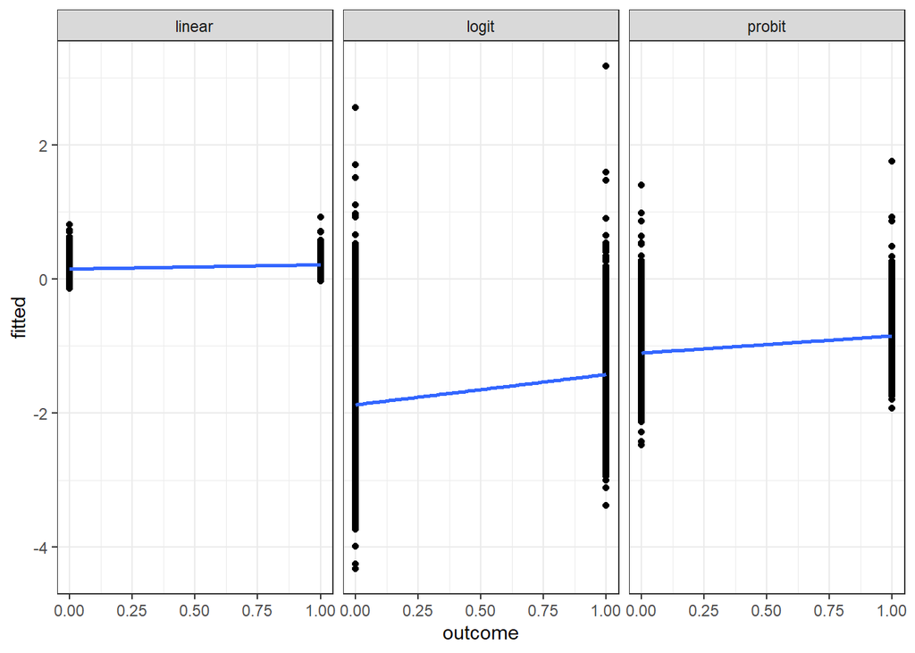

```r
data.frame(
  outcome = loans_data$not.fully.paid,
  linear = predict(LPMmodel, loans_data),
  probit = predict(olsprobit, loans_data),
  logit = predict(olslogit, loans_data)
) %>%
  pivot_longer(-outcome, names_to = "model_type", values_to = "fitted") %>%
  ggplot(aes(outcome, y = fitted)) +
  geom_point() +
  stat_smooth(formula = "y ~ x", se = FALSE, method = "lm") +
  facet_wrap(~ model_type) +
  theme_bw()
```

```r
##creates summaries of each of the individual models
library(margins)
library(aod)
margins_summary(LPMmodel)
```

|  | factor | AME | SE | z | p | lower | upper |
| --- | --- | --- | --- | --- | --- | --- | --- |
| 1 | credit.policy | -6.054819e-02 | 1.195572e-02 | -5.0643685 | 4.097563e-07 | -8.398098e-02 | -3.711540e-02 |
| 2 | days.with.credit.line | 1.835418e-06 | 1.664942e-06 | 1.1023915 | 2.702915e-01 | -1.427809e-06 | 5.098645e-06 |
| 3 | delinq.2yrs | -1.269931e-02 | 7.125833e-03 | -1.7821508 | 7.472465e-02 | -2.666568e-02 | 1.267067e-03 |
| 4 | dti | -3.017346e-04 | 5.862491e-04 | -0.5146867 | 6.067719e-01 | -1.450762e-03 | 8.472924e-04 |
| 5 | fico | -9.847386e-04 | 1.784226e-04 | -5.5191371 | 3.406684e-08 | -1.334440e-03 | -6.350368e-04 |
| 6 | inq.last.6mths | 1.467790e-02 | 2.001183e-03 | 7.3346091 | 2.223696e-13 | 1.075565e-02 | 1.860015e-02 |
| 7 | installment | 1.496124e-04 | 2.287994e-05 | 6.5390225 | 6.192222e-11 | 1.047686e-04 | 1.944563e-04 |
| 8 | int.rate | 1.653198e-01 | 2.344874e-01 | 0.7050264 | 4.807938e-01 | -2.942670e-01 | 6.249066e-01 |
| 9 | log.annual.inc | -4.926555e-02 | 7.479870e-03 | -6.5864186 | 4.505623e-11 | -6.392583e-02 | -3.460528e-02 |
| 10 | public.rec | 4.022459e-02 | 1.421822e-02 | 2.8290874 | 4.668094e-03 | 1.235739e-02 | 6.809180e-02 |

[output cut: 8 more lines]

[output not shown]

```r
margins_summary(olsprobit)
```

|  | factor | AME | SE | z | p | lower | upper |
| --- | --- | --- | --- | --- | --- | --- | --- |
| 1 | credit.policy | -4.469032e-02 | 1.095371e-02 | -4.0799242 | 4.505040e-05 | -6.615920e-02 | -2.322143e-02 |
| 2 | days.with.credit.line | 1.710327e-06 | 1.664642e-06 | 1.0274446 | 3.042112e-01 | -1.552311e-06 | 4.972964e-06 |
| 3 | delinq.2yrs | -1.202086e-02 | 7.006384e-03 | -1.7157008 | 8.621683e-02 | -2.575312e-02 | 1.711402e-03 |
| 4 | dti | -1.237022e-04 | 5.770851e-04 | -0.2143570 | 8.302687e-01 | -1.254768e-03 | 1.007364e-03 |
| 5 | fico | -1.085823e-03 | 1.778725e-04 | -6.1045017 | 1.031219e-09 | -1.434447e-03 | -7.371992e-04 |
| 6 | inq.last.6mths | 1.151869e-02 | 1.796014e-03 | 6.4134748 | 1.422397e-10 | 7.998568e-03 | 1.503881e-02 |
| 7 | installment | 1.510781e-04 | 2.216035e-05 | 6.8174946 | 9.264188e-12 | 1.076446e-04 | 1.945115e-04 |
| 8 | int.rate | 2.155252e-01 | 2.229906e-01 | 0.9665215 | 3.337833e-01 | -2.215284e-01 | 6.525788e-01 |
| 9 | log.annual.inc | -5.083426e-02 | 7.536390e-03 | -6.7451740 | 1.528438e-11 | -6.560531e-02 | -3.606321e-02 |
| 10 | public.rec | 3.278747e-02 | 1.278747e-02 | 2.5640309 | 1.034643e-02 | 7.724488e-03 | 5.785046e-02 |

[output cut: 8 more lines]

[output not shown]

```r
margins_summary(olslogit)
```

|  | factor | AME | SE | z | p | lower | upper |
| --- | --- | --- | --- | --- | --- | --- | --- |
| 1 | credit.policy | -4.369957e-02 | 1.062244e-02 | -4.11389271 | 3.890423e-05 | -6.451916e-02 | -2.287997e-02 |
| 2 | days.with.credit.line | 1.530238e-06 | 1.673364e-06 | 0.91446845 | 3.604708e-01 | -1.749494e-06 | 4.809971e-06 |
| 3 | delinq.2yrs | -1.133371e-02 | 7.006461e-03 | -1.61760786 | 1.057471e-01 | -2.506612e-02 | 2.398705e-03 |
| 4 | dti | -1.368973e-05 | 5.763985e-04 | -0.02375047 | 9.810517e-01 | -1.143410e-03 | 1.116031e-03 |
| 5 | fico | -1.122538e-03 | 1.788274e-04 | -6.27721361 | 3.446944e-10 | -1.473033e-03 | -7.720426e-04 |
| 6 | inq.last.6mths | 1.074084e-02 | 1.713767e-03 | 6.26738742 | 3.671559e-10 | 7.381920e-03 | 1.409976e-02 |
| 7 | installment | 1.517378e-04 | 2.197053e-05 | 6.90642503 | 4.970194e-12 | 1.086764e-04 | 1.947992e-04 |
| 8 | int.rate | 1.632770e-01 | 2.184645e-01 | 0.74738446 | 4.548315e-01 | -2.649056e-01 | 5.914595e-01 |
| 9 | log.annual.inc | -4.987792e-02 | 7.556785e-03 | -6.60041531 | 4.100076e-11 | -6.468894e-02 | -3.506689e-02 |
| 10 | public.rec | 3.183924e-02 | 1.222251e-02 | 2.60496850 | 9.188271e-03 | 7.883571e-03 | 5.579491e-02 |

[output cut: 8 more lines]

[output not shown]

```r
#LR test for LPM model and probit
lrtest(LPMmodel, olsprobit)
```

|  | #Df | LogLik | Df | Chisq | Pr(>Chisq) |
| --- | --- | --- | --- | --- | --- |
| 1 | 20 | -3644.098 | NA | NA | NA |
| 2 | 19 | -3893.833 | -1 | 499.4698 | 1.239744e-110 |

[output not shown]

```r
#LR test for Logit and Probit
lrtest(olslogit, olsprobit)
```

|  | #Df | LogLik | Df | Chisq | Pr(>Chisq) |
| --- | --- | --- | --- | --- | --- |
| 1 | 19 | -3897.570 | NA | NA | NA |
| 2 | 19 | -3893.833 | 0 | 7.473455 | 0 |

[output not shown]

```r
wald.test(Sigma = vcov(LPMmodel), b = coef(LPMmodel), Terms = 1:14)
```

```
## Wald test:
## ----------
##
## Chi-squared test:
## X2 = 379.6, df = 14, P(> X2) = 0.0
```

```r
wald.test(Sigma = vcov(LPMmodel), b = coef(LPMmodel), Terms = 3:3)
```

```
## Wald test:
## ----------
##
## Chi-squared test:
## X2 = 24.7, df = 1, P(> X2) = 6.8e-07
```

```r
wald.test(Sigma = vcov(olsprobit), b = coef(olsprobit), Terms = 3:3)
```

```
## Wald test:
## ----------
##
## Chi-squared test:
## X2 = 25.1, df = 1, P(> X2) = 5.5e-07
```

```r
wald.test(Sigma = vcov(olslogit), b = coef(olslogit), Terms = 3:3)
```

```
## Wald test:
## ----------
##
## Chi-squared test:
## X2 = 24.3, df = 1, P(> X2) = 8.3e-07
```

```r
wald.test(Sigma = vcov(LPMmodel), b = coef(LPMmodel), Terms = 4:4)
```

```
## Wald test:
## ----------
##
## Chi-squared test:
## X2 = 19.2, df = 1, P(> X2) = 1.2e-05
```

```r
wald.test(Sigma = vcov(olsprobit), b = coef(olsprobit), Terms = 4:4)
```

```
## Wald test:
## ----------
##
## Chi-squared test:
## X2 = 18.3, df = 1, P(> X2) = 1.8e-05
```

```r
wald.test(Sigma = vcov(olslogit), b = coef(olslogit), Terms = 4:4)
```

```
## Wald test:
## ----------
##
## Chi-squared test:
## X2 = 18.9, df = 1, P(> X2) = 1.3e-05
```

```r
wald.test(Sigma = vcov(LPMmodel), b = coef(LPMmodel), Terms = 5:5)
```

```
## Wald test:
## ----------
##
## Chi-squared test:
## X2 = 0.52, df = 1, P(> X2) = 0.47
```

```r
wald.test(Sigma = vcov(olsprobit), b = coef(olsprobit), Terms = 5:5)
```

```
## Wald test:
## ----------
##
## Chi-squared test:
## X2 = 0.38, df = 1, P(> X2) = 0.54
```

```r
wald.test(Sigma = vcov(olslogit), b = coef(olslogit), Terms = 5:5)
```

```
## Wald test:
## ----------
##
## Chi-squared test:
## X2 = 0.32, df = 1, P(> X2) = 0.57
```

We used the wald test on multiple variables on each model and they all produced about the same results. Statistically significant variables had low p values and variables with low significants had high p values. Since all models have almost the same level of significance for each variable this result makes sense.